# Tidy Asset Pricing

# Introduction

This note is a replication of [Tidy Asset Pricing](https://christophscheuch.github.io/post/asset-pricing/crsp-sample/) by Christoph Scheuch.

- Here is the options that run through the entire note

```r
# conducts heavy (> 1hr) computation
heavy <- FALSE

# restrict sample until Dec 2019, consistent with
# the original note
sample_restrict <- FALSE
```

# Part I: The CRSP Sample

- Packages

```r
pacman::p_load(tidyverse, scales, viridis, vroom,
               lubridate, here, slider, moments,
               corrr, kableExtra, broom, sandwich,
               matsuno, FamaFrench)
```

- Load data

```r
tbl.crsp_msf <- vroom(file = here("input/CRSP_msf.csv"),
                      col_types = cols(.default = col_character()),
                      col_select = c(PERMNO, date, RET, SHROUT, ALTPRC,
                                     EXCHCD, SHRCD, SICCD, DLRET, DLSTCD))
colnames(tbl.crsp_msf) <- str_to_lower(colnames(tbl.crsp_msf))
```

- Make sure that all relevant vars are correctly parsed

```r
tbl.crsp_monthly <- tbl.crsp_msf %>%
  transmute(permno = as.integer(permno),       # security identifier
            date = ymd(date),                  # date of the observation
            month = floor_date(date, "month"), # month identifier
            ret = as.numeric(ret) * 100,       # return (in percent)
            shrout = as.numeric(shrout),       # shares outstanding (in thousands)
            altprc = as.numeric(altprc),       # last traded price in a month
            exchcd = as.integer(exchcd),       # exchange code
            shrcd = as.integer(shrcd),         # share code
            siccd = as.integer(siccd),         # industry code
            dlret = as.numeric(dlret) * 100,   # delisting return (in percent)
            dlstcd = as.integer(dlstcd)        # delisting code
  )
rm(tbl.crsp_msf)
```

- Focus on US-based common stocks

```r
tbl.crsp_monthly <- tbl.crsp_monthly %>%
  filter(shrcd %in% c(10, 11))
```

- Remove duplicates

```r
NROW(tbl.crsp_monthly)
```

```
## [1] 3718022
```

```r
tbl.crsp_montly_duplicate <- tbl.crsp_monthly %>%
  group_by_all() %>%
  filter(n() > 1) %>%
  ungroup()
cat("The number of duplicated records are " %+%
      NROW(tbl.crsp_montly_duplicate))
```

```
## The number of duplicated records are 57532
```

```r
cat("The percentage of duplicated records are " %+%
      (round(NROW(tbl.crsp_montly_duplicate)/NROW(tbl.crsp_monthly), 4) * 100) %+% "%")
```

```
## The percentage of duplicated records are 1.55%
```

```r
# remove duplicates
tbl.crsp_monthly <- tbl.crsp_monthly %>%
  distinct(permno, date, .keep_all = TRUE)
```

- Compute market cap.
  - `shrout` is in thousands, so`mktcap` is in millions of dollars.
  - We adjust the market cap by cpi.

```r
tbl.crsp_monthly <- tbl.crsp_monthly %>%
  mutate(mktcap = abs(shrout * altprc) / 1000,
         mktcap = if_else(mktcap == 0, NA_real_, mktcap))

tbl.cpi_raw <- readr::read_csv(here("input/CPIAUCNS.csv"))
tbl.cpi <- tbl.cpi_raw %>%
  filter(DATE <= max(tbl.crsp_monthly$date)) %>%
  transmute(month = floor_date(DATE, "month"),
            cpi = CPIAUCNS) %>%
  arrange(month) %>%
  mutate(cpi = cpi/last(cpi))

tbl.crsp_monthly <- tbl.crsp_monthly %>%
  left_join(tbl.cpi, by = c("month")) %>%
  mutate(mktcap_cpi = mktcap / cpi)
```

- Create stock exchange category.
  - The value `3*` means when-issued trading

```r
tbl.crsp_monthly <- tbl.crsp_monthly %>%
  mutate(exchange = case_when(exchcd %in% c(1, 31) ~ "NYSE",
                              exchcd %in% c(2, 32) ~ "AMEX",
                              exchcd %in% c(3, 33) ~ "NASDAQ",
                              TRUE ~ "other"))
```

- Number of securities by exchange

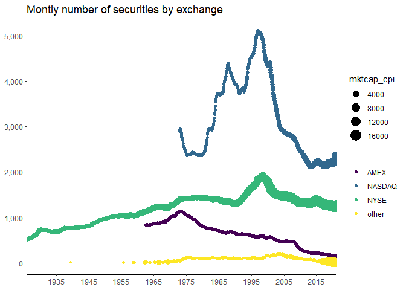

```r
fig.securities <- tbl.crsp_monthly %>%
  group_by(exchange, date) %>%
  summarise(n = n(), mktcap_cpi = mean(mktcap_cpi, na.rm = TRUE)) %>%
  ungroup() %>%
  ggplot(aes(date, n, colour = exchange, linetype = exchange)) +
  geom_point(aes(size = mktcap_cpi)) +
  labs(x = NULL, y = NULL, color = NULL, linetype = NULL,
       title = "Montly number of securities by exchange") +
  scale_x_date(expand = c(0, 0), date_breaks = "10 years", date_labels = "%Y") +
  scale_y_continuous(labels = comma, breaks = pretty_breaks()) +
  theme_classic() +
  scale_color_viridis_d()
fig.securities
```

```r
tbl.crsp_monthly <- tbl.crsp_monthly %>%
  mutate(industry = case_when(
    siccd >= 1 & siccd <= 999 ~ "Agriculture",
    siccd >= 1000 & siccd <= 1499 ~ "Mining",
    siccd >= 1500 & siccd <= 1799 ~ "Construction",
    siccd >= 2000 & siccd <= 3999 ~ "Manufacturing",
    siccd >= 4000 & siccd <= 4999 ~ "Transportation",
    siccd >= 5000 & siccd <= 5199 ~ "Wholesale",
    siccd >= 5200 & siccd <= 5999 ~ "Retail",
    siccd >= 6000 & siccd <= 6799 ~ "Finance",
    siccd >= 7000 & siccd <= 8999 ~ "Services",
    siccd >= 9000 & siccd <= 9999 ~ "Public",
    TRUE ~ "Missing"))
```

- Industry distribution

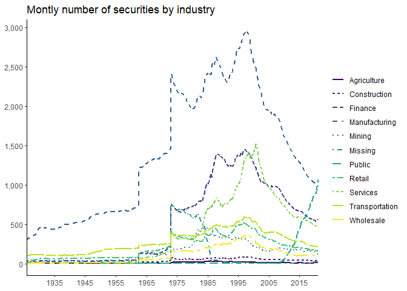

```r
fig.industries <- tbl.crsp_monthly %>%
  filter(!is.na(industry)) %>%
  count(industry, date) %>%
  ggplot(aes(date, n, color = industry, linetype = industry)) +
  geom_line(size = 1) +
  labs(x = NULL, y = NULL, color = NULL, linetype = NULL,
       title = "Montly number of securities by industry") +
  scale_x_date(expand = c(0, 0), date_breaks = "10 years", date_labels = "%Y") +
  scale_y_continuous(labels = comma, breaks = pretty_breaks()) +
  theme_classic() +
  scale_color_viridis_d()
fig.industries
```

- Compute return with taking delisting into account

```r
tbl.crsp_monthly <- tbl.crsp_monthly %>%
  mutate(ret_adj = case_when(is.na(dlstcd) ~ ret,
                             !is.na(dlstcd) & !is.na(dlret) ~ dlret,
                             dlstcd %in% c(500, 520, 580, 584) |
                              (dlstcd >= 551 & dlstcd <= 574) ~ -30,
                             TRUE ~ -100))

summary(select(tbl.crsp_monthly, ret, ret_adj))
```

```
##       ret             ret_adj
##  Min.   : -99.36   Min.   :-100.00
##  1st Qu.:  -6.42   1st Qu.:  -6.45
##  Median :   0.00   Median :   0.00
##  Mean   :   1.21   Mean   :   1.04
##  3rd Qu.:   7.04   3rd Qu.:   6.99
##  Max.   :2400.00   Max.   :2400.00
##  NA's   :124910    NA's   :105994
```

- Market return by CRSP

```r
tbl.crsp_si <- read_csv(here("input/crsp_si.csv"))
colnames(tbl.crsp_si) <- str_to_lower(colnames(tbl.crsp_si))

tbl.crsp_monthly_market <- tbl.crsp_si %>%
  transmute(month = floor_date(ymd(date), "month"),
            vwretd = vwretd * 100,
            ewretd = ewretd * 100)

tbl.crsp_monthly <- tbl.crsp_monthly_market %>%
  left_join(tbl.crsp_monthly, by = "month")
```

- Risk free returns by French

```r
tbl.factors_ff_monthly <-
  read_csv(here("input/F-F_Research_Data_Factors.csv"),
           skip = 3,
           col_types = c("i", "d", "d", "d", "d")) %>%
  rename(date = 1) %>%
  mutate(digits = floor(log10(date)) + 1) %>%
  filter(digits == 6) %>%    # delete yearly data
  transmute(month = floor_date(ymd(paste0(date, "01")), "month"),
            rf_ff = as.numeric(RF),
            mkt_ff = as.numeric(`Mkt-RF`) + as.numeric(RF),
            smb_ff = as.numeric(SMB),
            hml_ff = as.numeric(HML))
tbl.crsp_monthly <- tbl.crsp_monthly %>%
  left_join(tbl.factors_ff_monthly, by = "month")
```

- Plot cumulative returns

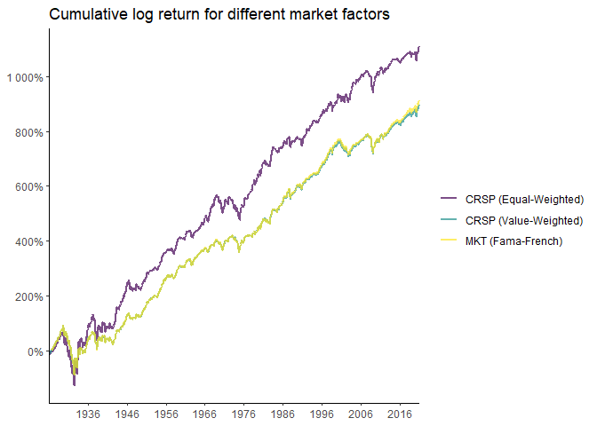

```r
tbl.market <- tbl.crsp_monthly %>%
  distinct(date, vwretd, ewretd, mkt_ff) %>%
  pivot_longer(-date, names_to = "portfolio", values_to = "return") %>%
  na.omit() %>%
  group_by(portfolio) %>%
  arrange(date) %>%
  mutate(cum_return = cumsum(log(1 + return/100))) %>%
  ungroup()

fig.market <- tbl.market %>%
  mutate(portfolio = case_when(
    portfolio == "vwretd" ~ "CRSP (Value-Weighted)",
    portfolio == "ewretd" ~ "CRSP (Equal-Weighted)",
    portfolio == "mkt_ff" ~ "MKT (Fama-French)")) %>%
  ggplot(aes(x = date, y = cum_return, colour = portfolio)) +
  geom_line(size = 1, alpha = .7) +
  labs(x = NULL, y = NULL, colour = NULL,
       title = "Cumulative log return for different market factors") +
  scale_x_date(expand = c(0, 0), date_breaks = "10 years", date_labels = "%Y") +
  scale_y_continuous(labels = percent, breaks = pretty_breaks()) +
  theme_classic() +
  scale_color_viridis_d()
fig.market
```

- Future return
  - We cannot simply use `lead()` to creat 1-month future return. This is because some records have jumps in month. For example, if `2020-02-01` has `2020-04-01` as the next record, `lead(month)` wrongly indicate the April return as a one-month future return of the February return. On the other hand, the method below correctly gives `NA` as a one-month future return of the February return.

```r
# one way
tbl.crsp_monthly_f1 <- tbl.crsp_monthly %>%
  transmute(permno = permno,
            month = floor_date(date, "month") %m-% months(1),
            ret_excess_f1 = ret - rf_ff,
            ret_adj_excess_f1 = ret_adj - rf_ff,
            mkt_ff_excess_f1 = mkt_ff - rf_ff)

tbl.crsp_monthly <- tbl.crsp_monthly %>%
  left_join(tbl.crsp_monthly_f1, by = c("permno", "month"))
```

- Finally, we check the descriptive statistics and save data.

```r
tbl.crsp_monthly <- tbl.crsp_monthly %>%
  arrange(permno, month)

write_rds(tbl.crsp_monthly, here("middle/crsp_monthly.rds"))

summary(tbl.crsp_monthly)
```

```
##      month                vwretd             ewretd            permno
##  Min.   :1925-12-01   Min.   :-29.1731   Min.   :-31.275   Min.   :10000
##  1st Qu.:1977-06-01   1st Qu.: -1.7600   1st Qu.: -1.987   1st Qu.:21768
##  Median :1991-04-01   Median :  1.3000   Median :  1.418   Median :49330
##  Mean   :1988-07-05   Mean   :  0.9421   Mean   :  1.139   Mean   :50178
##  3rd Qu.:2002-09-01   3rd Qu.:  3.9336   3rd Qu.:  4.277   3rd Qu.:78829
##  Max.   :2020-12-01   Max.   : 39.4143   Max.   : 66.810   Max.   :93436
##                       NA's   :497        NA's   :497
##       date                 ret              shrout             altprc
##  Min.   :1925-12-31   Min.   : -99.36   Min.   :       0   Min.   : -1832.5
##  1st Qu.:1977-06-30   1st Qu.:  -6.42   1st Qu.:    2204   1st Qu.:     1.7
##  Median :1991-04-30   Median :   0.00   Median :    6937   Median :    10.8
##  Mean   :1988-08-03   Mean   :   1.21   Mean   :   41815   Mean   :    28.2
##  3rd Qu.:2002-09-30   3rd Qu.:   7.04   3rd Qu.:   23916   3rd Qu.:    25.4
##  Max.   :2020-12-31   Max.   :2400.00   Max.   :29206400   Max.   :347815.0
##                       NA's   :124910    NA's   :3717       NA's   :73703
##      exchcd           shrcd           siccd          dlret
##  Min.   :-2.000   Min.   :10.00   Min.   :   0   Min.   :-100
##  1st Qu.: 1.000   1st Qu.:10.00   1st Qu.:3080   1st Qu.: -10
##  Median : 2.000   Median :11.00   Median :3843   Median :   0
##  Mean   : 2.108   Mean   :10.73   Mean   :4530   Mean   :  -8
##  3rd Qu.: 3.000   3rd Qu.:11.00   3rd Qu.:6035   3rd Qu.:   3
##  Max.   :33.000   Max.   :11.00   Max.   :9999   Max.   :1000
##                                   NA's   :2418   NA's   :3667294
##      dlstcd            mktcap               cpi            mktcap_cpi
##  Min.   :100       Min.   :      0.0   Min.   :0.04837   Min.   :      0.0
##  1st Qu.:231       1st Qu.:     16.1   1st Qu.:0.23304   1st Qu.:     48.7
##  Median :233       Median :     68.4   Median :0.51905   Median :    185.7
##  Mean   :331       Mean   :   1579.5   Mean   :0.49476   Mean   :   2344.5
##  3rd Qu.:552       3rd Qu.:    369.9   3rd Qu.:0.69450   3rd Qu.:    838.9
##  Max.   :591       Max.   :2255969.1   Max.   :1.00000   Max.   :2255969.1
##  NA's   :3663415   NA's   :73839                         NA's   :73839
##    exchange           industry            ret_adj            rf_ff
##  Length:3688711     Length:3688711     Min.   :-100.00   Min.   :-0.060
##  Class :character   Class :character   1st Qu.:  -6.45   1st Qu.: 0.140
##  Mode  :character   Mode  :character   Median :   0.00   Median : 0.380
##                                        Mean   :   1.04   Mean   : 0.366
##                                        3rd Qu.:   6.99   3rd Qu.: 0.510
##                                        Max.   :2400.00   Max.   : 1.350
##                                        NA's   :105994    NA's   :3627
##      mkt_ff            smb_ff            hml_ff        ret_excess_f1
##  Min.   :-29.100   Min.   :-17.290   Min.   :-14.020   Min.   : -99.52
##  1st Qu.: -1.750   1st Qu.: -1.710   1st Qu.: -1.400   1st Qu.:  -6.79
##  Median :  1.300   Median :  0.100   Median :  0.230   Median :  -0.35
##  Mean   :  0.963   Mean   :  0.147   Mean   :  0.317   Mean   :   0.84
##  3rd Qu.:  3.930   3rd Qu.:  1.870   3rd Qu.:  1.760   3rd Qu.:   6.70
##  Max.   : 38.950   Max.   : 36.560   Max.   : 35.610   Max.   :2399.66
##  NA's   :3627      NA's   :3627      NA's   :3627      NA's   :128086
##  ret_adj_excess_f1 mkt_ff_excess_f1
##  Min.   :-101.31   Min.   :-29.130
##  1st Qu.:  -6.84   1st Qu.: -2.040
##  Median :  -0.37   Median :  1.020
##  Mean   :   0.68   Mean   :  0.595
##  3rd Qu.:   6.66   3rd Qu.:  3.570
##  Max.   :2399.66   Max.   : 38.850
##  NA's   :109226    NA's   :29435
```

- Now that we saved the data, we clear all objects

```r
rm(tbl.crsp_monthly, tbl.crsp_monthly_f1)
```

# Part II: Beta and Stock Return

- In this section, we estimate $beta$ and examine its relation to stock returns.
- First, we read the data prepared in the previous section and compute thee excess returns

```r
tbl.crsp_monthly <- read_rds(here("middle/crsp_monthly.rds")) %>%
  mutate(ret_adj_excess = ret_adj - rf_ff,
         mkt_excess = mkt_ff - rf_ff) %>%
  select(permno, month, mkt_excess, ret_adj_excess)
```

## Estimation

- Now, we estimate beta for all stocks

```r
# # dtplyr (sequential; slow)
# system.time(
# tbl.betas_monthly <- dtplyr::lazy_dt(tbl.crsp_monthly) %>%
#   group_by(permno) %>%
#   arrange(month) %>%
#   mutate(
#     beta_1y = FamaFrench::rolling_capm_regression(
#       cur_data(),
#       window = 12,
#       freq = "monthly"),
#     beta_2y = FamaFrench::rolling_capm_regression(
#       cur_data(),
#       window = 24,
#       freq = "monthly"),
#     FamaFrench::rolling_capm_regression(
#       cur_data(),
#       window = 36,
#       freq = "monthly"),
#     FamaFrench::rolling_capm_regression(
#       cur_data(),
#       window = 60,
#       freq = "monthly")) %>%
#   ungroup() %>%
#   collect() %>%
#   select(permno, month, starts_with("beta"))
# )
```

```r
if(heavy){
# parallelized computation
window_vec <- c(12, 24, 36, 60)

# register
library(doParallel)
cl <- parallel::makePSOCKcluster(parallel::detectCores(logical = FALSE))
doParallel::registerDoParallel(cl)

# computation
system.time(
result <- foreach(
  i = seq_along(window_vec),
  .packages = c('dplyr', 'purrr', "slider",
                'FamaFrench','tidyr')
 ) %dopar% {
  dtplyr::lazy_dt(tbl.crsp_monthly) %>%
  group_by(permno) %>%
  arrange(permno, month) %>%
  mutate(beta = rolling_capm_regression(cur_data(),
                                      window = window_vec[i],
                                      freq = "monthly"),
         window = c("1Y", "2Y", "3Y", "5Y")[i]) %>%
  ungroup() %>%
  collect() %>%
  unnest(beta) %>%
  select(permno, month, beta, se, window)
  }
)

# kill finished tasks
parallel::stopCluster(cl)

# combine results
tbl.betas_monthly <- bind_rows(result)

# save the data
write_rds(tbl.betas_monthly, here("middle/betas_monthly.rds"))
rm(tbl.betas_monthly)
}
```

- For the monthly data, using `{roll}` package is much faster.

```r
# parallelized computation
window_vec <- c(12, 24, 36, 60)

# register
library(doParallel)
cl <- parallel::makePSOCKcluster(parallel::detectCores(logical = FALSE))
doParallel::registerDoParallel(cl)

system.time(
result <- foreach(
  i = seq_along(window_vec),
  .packages = c('dplyr', 'purrr', "slider",
                'FamaFrench','tidyr', 'roll')
  ) %dopar% {
    tbl.crsp_monthly %>%
      group_by(permno) %>%
      arrange(permno, month) %>%
      summarise(
        roll_rolling_capm_regression(
          cur_data(),
          window = window_vec[i],
          freq = "monthly"),
        window = c("1Y", "2Y", "3Y", "5Y")[i],
        month = month,
        mkt_excess = mkt_excess,
        ret_adj_excess = ret_adj_excess,
        .groups = "drop") %>%
      ungroup()
  }
)
```

```
##    user  system elapsed
##    3.23    0.95   35.18
```

```r
# kill finished tasks
parallel::stopCluster(cl)

# combine results
tbl.betas_monthly <- bind_rows(result)

# save the data
write_rds(tbl.betas_monthly, here("middle/betas_monthly.rds"))
rm(tbl.betas_monthly, result)
```

## Descriptive statistics

- Now we conduct descriptive analysis of beta.

```r
tbl.betas_monthly <- read_rds(here("middle/betas_monthly.rds"))
tbl.crsp_monthly <- read_rds(here("middle/crsp_monthly.rds"))

if(sample_restrict){
  tbl.betas_monthly <- tbl.betas_monthly %>%
    filter(month <= ymd("2019-12-31"))

  tbl.crsp_monthly <- tbl.crsp_monthly %>%
    filter(month <= ymd("2019-12-31"))
}

tbl.betas <- tbl.crsp_monthly %>%
  select(permno, month, ends_with("f1"),
         mktcap, mktcap_cpi, exchange) %>%
  left_join(tbl.betas_monthly, by = c("permno", "month"))

# wide data that is consistent with the original note
tbl.betas_wide <- tbl.betas %>%
  select(permno, month, beta, window) %>%
  pivot_wider(names_from = window,
              values_from = beta,
              names_prefix = "beta_")

rm(tbl.betas_monthly)
```

- Plot the share of stock that are used in beta computation in each month.

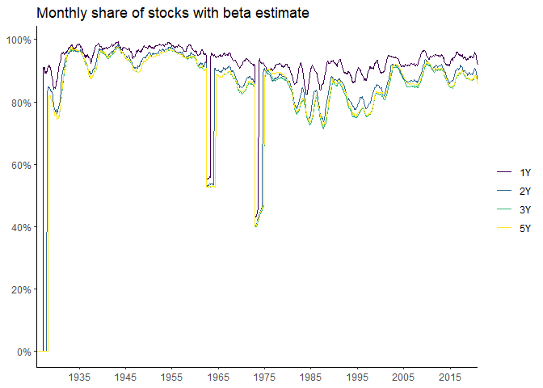

```r
tbl.coverage <- tbl.betas %>%
  select(month, permno, beta, window) %>%
  group_by(month, window) %>%
  summarise(share = n_distinct(permno[!is.na(beta)]) /
              n_distinct(permno),
            .groups = "drop")

fig.coverage <- tbl.coverage %>%
  mutate(window = factor(window,
                         levels = c("1Y", "2Y", "3Y", "5Y"))) %>%
  ggplot(aes(month, share, colour = window)) +
  geom_line() +
  labs(x = NULL, y = NULL, color = NULL, linetype = NULL,
       title = "Monthly share of stocks with beta estimate") +
  scale_x_date(expand = c(0, 0), date_breaks = "10 years",
               date_labels = "%Y") +
  scale_y_continuous(labels = percent, breaks = pretty_breaks()) +
  theme_classic() +
  scale_color_viridis_d()
fig.coverage
```

- How many of estimates are credible (t-value >= 2.0)?

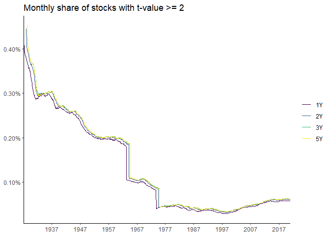

```r
tbl.betas %>%
  select(month, permno, beta, window, se) %>%
  mutate(t_val = beta / se) %>%
  na.omit() %>%
  group_by(month, window) %>%
  summarise(share = n_distinct(abs(t_val) >= 2) / n_distinct(t_val),
            .groups = "drop") %>%
  ggplot(aes(month, share, colour = window)) +
  geom_line() +
  labs(x = NULL, y = NULL, color = NULL, linetype = NULL,
       title = "Monthly share of stocks with t-value >= 2") +
  scale_x_date(expand = c(0, 0), date_breaks = "10 years",
               date_labels = "%Y") +
  scale_y_continuous(labels = percent, breaks = pretty_breaks()) +
  theme_classic() +
  scale_color_viridis_d()
```

- Next, we see the distribution of betas

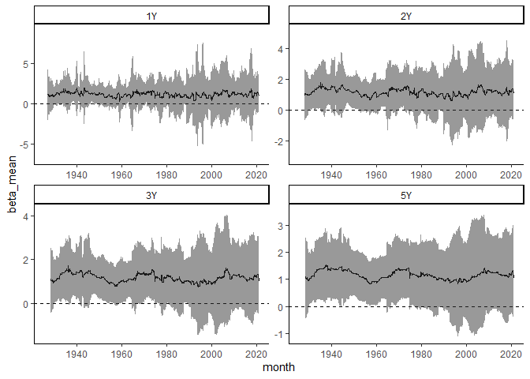

```r
# time series plot
tbl.betas %>%
  select(permno, month, beta, window) %>%
  group_by(month, window) %>%
  summarise(beta_mean = mean(beta, na.rm = TRUE),
            beta_sd = sd(beta, na.rm = TRUE),
            .groups = "drop") %>%
  mutate(upper = beta_mean + 1.96 * beta_sd,
         lower = beta_mean - 1.96 * beta_sd) %>%
  ggplot(aes(month, beta_mean)) +
  geom_line() +
  geom_hline(yintercept = 0, lty = 2) +
  geom_ribbon(aes(ymax = upper, ymin = lower), alpha = .5) +
  facet_wrap(~ window, scales = "free") +
  theme_classic()
```

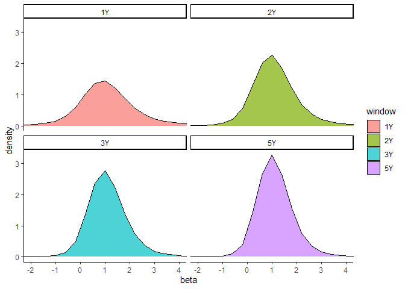

```r
# Histogram
tbl.betas %>%
  select(permno, month, beta, window) %>%
  ggplot(aes(x = beta, fill = window)) +
  geom_density(alpha = .7) +
  coord_cartesian(xlim = c(-2, 4)) +
  scale_x_continuous(breaks = pretty_breaks()) +
  facet_wrap(~window) +
  theme_classic()
```

- Now, the descriptive statistics. - The reason why 5-year window has more `n` than 3-year window is that we do not require monthly data to be consecutive. - If there is a jump in the monthly return data used in the regression, as the horizon gets longer, it is more likely to satisfied the sample size requirement (>24).

```r
# Descriptive stat
tbl.betas_ts <- tbl.betas %>%
  select(month, beta, window) %>%
  group_by(window, month) %>%
  na.omit() %>%
  summarise(mean = mean(beta),
            sd = sd(beta),
            skew = skewness(beta),
            kurt = kurtosis(beta),
            min = min(beta),
            q05 = quantile(beta, 0.05),
            q25 = quantile(beta, 0.25),
            q50 = quantile(beta, 0.50),
            q75 = quantile(beta, 0.75),
            q95 = quantile(beta, 0.95),
            max = max(beta),
            n = n(),
            .groups = "drop")

# summarise across month
tbl.betas_summary <- tbl.betas_ts %>%
  select(-month) %>%
  group_by(window) %>%
  summarise(across(.cols = everything(),
                   .fns = ~mean(.x),
                   na.rm = TRUE),
            .groups = "drop") %>%
  mutate(window = factor(window,
                         levels = c("1Y", "2Y", "3Y", "5Y"))) %>%
  arrange(window) %>%
  kable(digits = 2) %>%
  kable_styling(bootstrap_options =
                  c("striped", "hover", "condensed", "responsive"))
tbl.betas_summary
```

| window | mean | sd | skew | kurt | min | q05 | q25 | q50 | q75 | q95 | max | n |
| --- | --- | --- | --- | --- | --- | --- | --- | --- | --- | --- | --- | --- |
| 1Y | 1.15 | 1.17 | 0.72 | 20.81 | -7.59 | -0.41 | 0.48 | 1.05 | 1.73 | 3.06 | 12.41 | 2976.31 |
| 2Y | 1.16 | 0.83 | 0.60 | 9.68 | -3.93 | 0.03 | 0.63 | 1.08 | 1.61 | 2.59 | 7.38 | 2783.68 |
| 3Y | 1.17 | 0.73 | 0.56 | 7.27 | -2.82 | 0.17 | 0.69 | 1.09 | 1.57 | 2.43 | 5.97 | 2721.61 |
| 5Y | 1.17 | 0.65 | 0.43 | 8.65 | -2.56 | 0.27 | 0.73 | 1.10 | 1.53 | 2.30 | 5.25 | 2742.07 |

- Sanity check

```r
# Months that have more n for 5Y than 3Y
tbl.betas_ts %>% filter(window %in% c("3Y", "5Y")) %>% select(window, month, n) %>% arrange(month, window) %>% pivot_wider(names_from = window, values_from = n) %>% filter(`3Y` != `5Y`)
```

```
## # A tibble: 951 x 3
##    month       `3Y`  `5Y`
##    <date>     <int> <int>
##  1 1930-02-01   546   547
##  2 1930-08-01   548   549
##  3 1930-09-01   553   554
##  4 1930-10-01   559   560
##  5 1930-11-01   566   567
##  6 1930-12-01   571   572
##  7 1931-01-01   578   579
##  8 1931-02-01   585   586
##  9 1931-03-01   586   588
## 10 1931-04-01   594   598
## # ... with 941 more rows
```

```r
# Look at one example of such month
tbl.betas %>%
  select(permno, month, beta, window) %>%
  pivot_wider(id_cols = c(permno, month),
              names_from = window,
              values_from = beta) %>%
  filter(month == ymd("1931-04-01")) %>%
  select(permno, month, `3Y`, `5Y`)
```

```
## # A tibble: 728 x 4
##    permno month       `3Y`  `5Y`
##     <int> <date>     <dbl> <dbl>
##  1  10006 1931-04-01 0.647 0.689
##  2  10014 1931-04-01 0.915 0.785
##  3  10022 1931-04-01 0.509 0.573
##  4  10030 1931-04-01 0.669 0.698
##  5  10057 1931-04-01 1.64  1.44
##  6  10073 1931-04-01 2.47  2.55
##  7  10081 1931-04-01 2.02  2.06
##  8  10102 1931-04-01 1.12  1.06
##  9  10137 1931-04-01 1.69  1.63
## 10  10145 1931-04-01 0.978 0.986
## # ... with 718 more rows
```

```r
tbl.betas %>% filter(permno == 11180, month == ymd("1931-04-01"))
```

```
## # A tibble: 4 x 13
##   permno month      ret_excess_f1 ret_adj_excess_~ mkt_ff_excess_f1 mktcap
##    <int> <date>             <dbl>            <dbl>            <dbl>  <dbl>
## 1  11180 1931-04-01            NA               NA            -13.2   1.90
## 2  11180 1931-04-01            NA               NA            -13.2   1.90
## 3  11180 1931-04-01            NA               NA            -13.2   1.90
## 4  11180 1931-04-01            NA               NA            -13.2   1.90
## # ... with 7 more variables: mktcap_cpi <dbl>, exchange <chr>, beta <dbl>,
## #   se <dbl>, window <chr>, mkt_excess <dbl>, ret_adj_excess <dbl>
```

```r
# Look at one firm
x <- tbl.crsp_monthly %>%
  filter(permno == 11180, month <= ymd("1931-04-01"))
```

## Correlations

- We see cross-sectional correlations between each window of beta

```r
tbl.correlations  <- tbl.betas_wide %>%
  select(-permno) %>%
  na.omit() %>%
  group_by(month) %>%
  nest(betas = starts_with("beta")) %>%
  mutate(correlations = map(betas,
                            FamaFrench::compute_correlation)) %>%
  ungroup() %>%
  select(-betas) %>%
  unnest(correlations) %>%
  rename(type = term) %>%
  mutate(type = factor(type,
                       levels = paste0("beta_", c(1, 2, 3, 5), "Y"))) %>%
  group_by(type) %>%
  summarise(across(starts_with("beta"), mean,
                   na.rm = TRUE))

options(knitr.kable.NA = '')
tab.correlations <- tbl.correlations %>%
  kable(digits = 2) %>%
  kable_styling(bootstrap_options =
                  c("striped", "hover", "condensed", "responsive"))
tab.correlations
```

| type | beta_1Y | beta_2Y | beta_3Y | beta_5Y |
| --- | --- | --- | --- | --- |
| beta_1Y | 1.00 |  |  |  |
| beta_2Y | 0.76 | 1.00 |  |  |
| beta_3Y | 0.67 | 0.88 | 1.00 |  |
| beta_5Y | 0.59 | 0.78 | 0.89 | 1 |

## Persistence

- We compute the correlation with $\tau$ months of lag.

```r
vec.tau <- c(1, 3, 6, 12, 24, 36, 48, 60, 120)

# for all beta
beta_vec <- "beta_" %+% c(1, 2, 3, 5) %+% "Y"

## garbage collection
gc()
```

```
##             used   (Mb) gc trigger   (Mb)  max used   (Mb)
## Ncells   2503100  133.7    7089207  378.7   8861508  473.3
## Vcells 342751470 2615.0  727370128 5549.4 727369244 5549.4
```

```r
## register
library(doParallel)
options(future.globals.maxSize = 1.6 * 1024^3)  # 1.5Gb
cl <- parallel::makePSOCKcluster(4)
doParallel::registerDoParallel(cl)

result <- foreach(
    i = seq_along(beta_vec),
    .packages = c('dplyr', 'purrr', 'tidyr',
                  'FamaFrench','corrr',
                  'lubridate', 'matsuno')
  ) %dopar% {
    compute_persistence(tbl.betas_wide, !!sym(beta_vec[i]), vec.tau,
                        probs = c(.005, .995))
  }

## kill finished tasks
parallel::stopCluster(cl)

# bind the result
tab.persistence <- reduce(result, left_join, by = "tau") %>%
  kable(digits = 2) %>%
  kable_styling(bootstrap_options = c("striped", "hover", "condensed", "responsive"))
tab.persistence
```

| tau | beta_1Y | beta_2Y | beta_3Y | beta_5Y |
| --- | --- | --- | --- | --- |
| 1 | 0.92 | 0.97 | 0.98 | 0.99 |
| 3 | 0.78 | 0.91 | 0.95 | 0.97 |
| 6 | 0.58 | 0.82 | 0.90 | 0.95 |
| 12 | 0.24 | 0.66 | 0.80 | 0.89 |
| 24 | 0.22 | 0.36 | 0.61 | 0.79 |
| 36 | 0.20 | 0.34 | 0.43 | 0.69 |
| 48 | 0.19 | 0.32 | 0.40 | 0.58 |
| 60 | 0.18 | 0.30 | 0.38 | 0.47 |
| 120 | 0.14 | 0.23 | 0.29 | 0.37 |

## Portfolio Analysis

- Does beta positively associated with future returns, as the CAPM predicts?
- We construct portfolios based on estimated betas.
  - Specifically, for stock of company $i$ at time (month) $t$, we estimated beta using the past $j \in \{1, 2, 3, 5\}$ years of data.
  - Then, for each month and the estimation window $j$, we computed the quantiles to divide the pool of betas in that month and window to portfolios of size `n_portfolios`.

```r
tbl.portfolios <-
  construct_univariate_portfolios(tbl.betas,
                                  nyse_breakpoints = TRUE)
```

- Given the portfolio returns, we test whether the portfolio’s return is statistically different from zero.
  - We estimate the mean excess reutnr and the CAPM alpha for each portfolio.
  - We use Newey and West (1987) $t$-stat with $6$ lags to correct for the serial correlation.

```r
# Table: Equal weighted
tab.portfolio_returns_ew <-
  estimate_portfolio_returns(tbl.portfolios, ret_ew) %>%
  reshape_portfolio_returns() %>%
  kable(digits = 2) %>%
  kable_styling(bootstrap_options = c("striped", "hover", "condensxed", "responsive")) %>%
  pack_rows("Estimation Period: 1 Year (Monthly Data) - Equal-Weighted Portfolio Returns", 1, 4) %>%
  pack_rows("Estimation Period: 2 Years (Monthly Data) - Equal-Weighted Portfolio Returns", 5, 8) %>%
  pack_rows("Estimation Period: 3 Years (Monthly Data) - Equal-Weighted Portfolio Returns", 9, 12) %>%
  pack_rows("Estimation Period: 5 Years (Monthly Data) - Equal-Weighted Portfolio Returns", 13, 16)
tab.portfolio_returns_ew
```

|  | 1 | 2 | 3 | 4 | 5 | 6 | 7 | 8 | 9 | 10 | 10-1 |
| --- | --- | --- | --- | --- | --- | --- | --- | --- | --- | --- | --- |
| **Estimation Period: 1 Year (Monthly Data) - Equal-Weighted Portfolio Returns** |  |  |  |  |  |  |  |  |  |  |  |
| Excess Return | 0.85 | 0.75 | 0.84 | 0.92 | 0.95 | 0.95 | 1.00 | 1.04 | 1.08 | 0.89 | 0.04 |
| t-stat | 3.28 | 3.38 | 3.70 | 3.92 | 3.84 | 3.57 | 3.64 | 3.57 | 3.61 | 2.62 | 0.24 |
| CAPM Alpha | 0.26 | 0.15 | 0.17 | 0.21 | 0.17 | 0.11 | 0.10 | 0.06 | 0.05 | -0.25 | -0.51 |
| t-stat | 1.66 | 1.21 | 1.44 | 1.79 | 1.38 | 0.86 | 0.77 | 0.46 | 0.34 | -1.42 | -3.66 |
| **Estimation Period: 2 Years (Monthly Data) - Equal-Weighted Portfolio Returns** |  |  |  |  |  |  |  |  |  |  |  |
| Excess Return | 0.79 | 0.75 | 0.87 | 0.93 | 0.95 | 1.04 | 1.05 | 1.06 | 1.02 | 0.95 | 0.16 |
| t-stat | 3.50 | 3.41 | 3.82 | 3.97 | 3.75 | 3.78 | 3.81 | 3.57 | 3.23 | 2.70 | 0.81 |
| CAPM Alpha | 0.30 | 0.18 | 0.22 | 0.22 | 0.17 | 0.21 | 0.15 | 0.09 | -0.02 | -0.20 | -0.50 |
| t-stat | 2.12 | 1.49 | 1.88 | 1.86 | 1.36 | 1.55 | 1.08 | 0.65 | -0.17 | -1.07 | -3.13 |
| **Estimation Period: 3 Years (Monthly Data) - Equal-Weighted Portfolio Returns** |  |  |  |  |  |  |  |  |  |  |  |
| Excess Return | 0.75 | 0.84 | 0.87 | 0.97 | 0.94 | 1.00 | 1.02 | 1.06 | 1.03 | 0.93 | 0.18 |
| t-stat | 3.45 | 3.86 | 3.94 | 3.94 | 3.71 | 3.68 | 3.61 | 3.48 | 3.22 | 2.59 | 0.85 |
| CAPM Alpha | 0.28 | 0.28 | 0.24 | 0.25 | 0.17 | 0.16 | 0.12 | 0.08 | 0.00 | -0.23 | -0.51 |
| t-stat | 2.03 | 2.32 | 2.06 | 2.09 | 1.39 | 1.21 | 0.86 | 0.58 | 0.01 | -1.21 | -3.10 |
| **Estimation Period: 5 Years (Monthly Data) - Equal-Weighted Portfolio Returns** |  |  |  |  |  |  |  |  |  |  |  |
| Excess Return | 0.75 | 0.82 | 0.90 | 0.92 | 1.02 | 1.00 | 0.98 | 1.06 | 0.99 | 0.95 | 0.20 |
| t-stat | 3.58 | 3.92 | 4.00 | 3.89 | 3.95 | 3.68 | 3.47 | 3.49 | 3.03 | 2.61 | 0.87 |
| CAPM Alpha | 0.30 | 0.27 | 0.26 | 0.22 | 0.24 | 0.17 | 0.08 | 0.09 | -0.06 | -0.21 | -0.51 |
| t-stat | 2.23 | 2.35 | 2.28 | 1.83 | 1.86 | 1.30 | 0.55 | 0.64 | -0.40 | -1.10 | -2.96 |

```r
# Table: Value weighted
tab.portfolio_returns_vw <-
  estimate_portfolio_returns(tbl.portfolios, ret_vw) %>%
  reshape_portfolio_returns() %>%
  kable(digits = 2) %>%
  kable_styling(bootstrap_options = c("striped", "hover", "condensed", "responsive")) %>%
  pack_rows("Estimation Period: 1 Year (Monthly Data) - Value-Weighted Portfolio Returns", 1, 4) %>%
  pack_rows("Estimation Period: 2 Years (Monthly Data) - Value-Weighted Portfolio Returns", 5, 8) %>%
  pack_rows("Estimation Period: 3 Years (Monthly Data) - Value-Weighted Portfolio Returns", 9, 12) %>%
  pack_rows("Estimation Period: 5 Years (Monthly Data) - Value-Weighted Portfolio Returns", 13, 16)
tab.portfolio_returns_vw
```

|  | 1 | 2 | 3 | 4 | 5 | 6 | 7 | 8 | 9 | 10 | 10-1 |
| --- | --- | --- | --- | --- | --- | --- | --- | --- | --- | --- | --- |
| **Estimation Period: 1 Year (Monthly Data) - Value-Weighted Portfolio Returns** |  |  |  |  |  |  |  |  |  |  |  |
| Excess Return | 0.46 | 0.43 | 0.66 | 0.66 | 0.75 | 0.65 | 0.69 | 0.77 | 0.84 | 0.68 | 0.22 |
| t-stat | 2.61 | 2.48 | 3.80 | 3.71 | 3.73 | 3.24 | 3.16 | 3.32 | 3.28 | 2.33 | 1.08 |
| CAPM Alpha | 0.02 | -0.07 | 0.10 | 0.04 | 0.06 | -0.08 | -0.11 | -0.11 | -0.13 | -0.43 | -0.44 |
| t-stat | 0.14 | -0.64 | 0.88 | 0.43 | 0.61 | -0.74 | -1.19 | -1.06 | -1.23 | -3.21 | -2.72 |
| **Estimation Period: 2 Years (Monthly Data) - Value-Weighted Portfolio Returns** |  |  |  |  |  |  |  |  |  |  |  |
| Excess Return | 0.46 | 0.51 | 0.59 | 0.73 | 0.71 | 0.76 | 0.70 | 0.73 | 0.71 | 0.81 | 0.35 |
| t-stat | 2.72 | 3.06 | 3.36 | 3.93 | 3.40 | 3.65 | 3.22 | 3.06 | 2.77 | 2.57 | 1.47 |
| CAPM Alpha | 0.07 | 0.04 | 0.04 | 0.10 | 0.00 | 0.02 | -0.12 | -0.16 | -0.26 | -0.35 | -0.42 |
| t-stat | 0.56 | 0.33 | 0.39 | 1.00 | 0.01 | 0.15 | -1.23 | -1.46 | -2.43 | -2.43 | -2.38 |
| **Estimation Period: 3 Years (Monthly Data) - Value-Weighted Portfolio Returns** |  |  |  |  |  |  |  |  |  |  |  |
| Excess Return | 0.39 | 0.55 | 0.59 | 0.73 | 0.66 | 0.69 | 0.65 | 0.76 | 0.74 | 0.73 | 0.34 |
| t-stat | 2.38 | 3.24 | 3.46 | 3.86 | 3.14 | 3.30 | 2.84 | 3.06 | 2.69 | 2.30 | 1.40 |
| CAPM Alpha | 0.02 | 0.07 | 0.05 | 0.12 | -0.04 | -0.05 | -0.16 | -0.12 | -0.26 | -0.42 | -0.44 |
| t-stat | 0.14 | 0.62 | 0.47 | 1.07 | -0.39 | -0.47 | -1.38 | -1.15 | -2.28 | -3.07 | -2.57 |
| **Estimation Period: 5 Years (Monthly Data) - Value-Weighted Portfolio Returns** |  |  |  |  |  |  |  |  |  |  |  |
| Excess Return | 0.46 | 0.54 | 0.58 | 0.64 | 0.70 | 0.69 | 0.71 | 0.70 | 0.72 | 0.76 | 0.29 |
| t-stat | 2.87 | 3.22 | 3.37 | 3.53 | 3.32 | 3.20 | 3.10 | 2.81 | 2.64 | 2.35 | 1.18 |
| CAPM Alpha | 0.10 | 0.06 | 0.04 | 0.03 | 0.01 | -0.07 | -0.10 | -0.19 | -0.27 | -0.39 | -0.49 |
| t-stat | 0.83 | 0.56 | 0.33 | 0.34 | 0.04 | -0.60 | -0.87 | -1.72 | -2.41 | -2.76 | -2.81 |

- Graphical Result

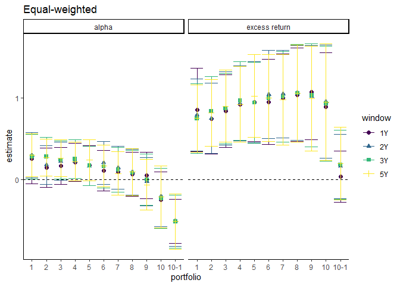

```r
# Equal-weighted
estimate_portfolio_returns(tbl.portfolios, ret_ew) %>%
  ggplot(aes(x = portfolio, y = estimate, colour = window)) +
  geom_point(aes(shape = window), size = 2) +
  geom_errorbar(aes(ymax = estimate + 1.96 * (estimate / nw_tstat),
                    ymin = estimate - 1.96 * (estimate / nw_tstat))) +
  geom_hline(yintercept = 0, lty = 2) +
  facet_wrap(~ type) +
  theme_classic() +
  scale_colour_viridis_d() +
  ggtitle("Equal-weighted")
```

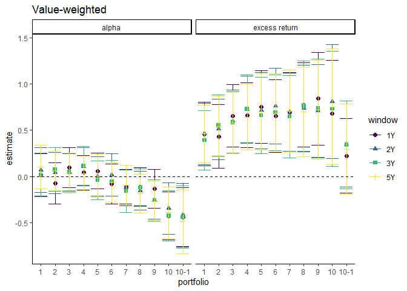

```r
# Value-weighted
estimate_portfolio_returns(tbl.portfolios, ret_vw) %>%
  ggplot(aes(x = portfolio, y = estimate, colour = window)) +
  geom_point(aes(shape = window), size = 2) +
  geom_errorbar(aes(ymax = estimate + 1.96 * (estimate / nw_tstat),
                    ymin = estimate - 1.96 * (estimate / nw_tstat))) +
  geom_hline(yintercept = 0, lty = 2) +
  facet_wrap(~ type) +
  theme_classic() +
  scale_colour_viridis_d() +
  ggtitle("Value-weighted")
```